# gi-ws-07-1

Heimann, Klöckner, Reitz, Rest

19 Dezember 2016

```r
path_saga <- "C:/Users/Christian/Desktop/saga_3.0.0_x64/saga_cmd.exe"
path_data <- "D:/Christian/Datenmanagement/data/gis/output/"
path_fun <- "D:/Christian/Datenmanagement/msc-phygeo-class-of-2016-Heimannc/fun/"
path_hydro <- paste0(path_data ,"hydro/")
library(raster)
library(gdalUtils)
source(paste0(path_fun, "fun_fill_sinks_saga.R"))
library(rgdal)
library(maptools)
library(mapview)

dtm_filled<- raster(paste0(path_hydro,"dtm_filled.tif"))
catch_pegel<-raster(paste0(path_hydro,"catchment_coord.tif"))

## time span auf 0 um default regen zu erkennen

cmd1 <- system(paste0(path_saga,
                      " sim_hydrology 1 ",
                      " -DEM ", paste0(path_hydro, "dtm_filled.sdat"),
                      " -FLOW ", paste0(path_hydro, "surface_runoff_0.sgrd"),
                      " -GAUGES ", paste0(path_hydro,"Pegel.shp"),
                      " -GAUGES_FLOW ", paste0(path_hydro, "Pegel_runoff_0.csv"),
                      " -TIME_SPAN=0 ",
                      " -TIME_STEP=0.1 "))

## time span auf 1h bei 24h

cmd2 <- system(paste0(path_saga,
                      " sim_hydrology 1 ",
                      " -DEM ", paste0(path_hydro, "dtm_filled.sdat"),
                      " -FLOW ", paste0(path_hydro, "surface_runoff_1.sgrd"),
                      " -GAUGES ", paste0(path_hydro,"Pegel.shp"),
                      " -GAUGES_FLOW ", paste0(path_hydro, "Pegel_runoff_1.csv"),
                      " -TIME_SPAN=24 ",
                      " -TIME_STEP=1 "))

## time span auf 2h bei 24h

cmd3 <- system(paste0(path_saga,
                      " sim_hydrology 1 ",
                      " -DEM ", paste0(path_hydro, "dtm_filled.sdat"),
                      " -FLOW ", paste0(path_hydro, "surface_runoff_2.sgrd"),
                      " -GAUGES ", paste0(path_hydro, "Pegel.shp"),
                      " -GAUGES_FLOW ", paste0(path_hydro, "Pegel_runoff_2.csv"),
                      " -TIME_SPAN=24 ",
                      " -TIME_STEP=2 "))

cmd4 <- system(paste0(path_saga,
                      " sim_hydrology 1 ",
                      " -DEM ", paste0(path_hydro, "dtm_filled.sdat"),
                      " -FLOW ", paste0(path_hydro, "surface_runoff_6.sgrd"),
                      " -GAUGES ", paste0(path_hydro, "Pegel.shp"),
                      " -GAUGES_FLOW ", paste0(path_hydro, "Pegel_runoff_6.csv"),
                      " -TIME_SPAN=24 ",
                      " -TIME_STEP=6 "))
```

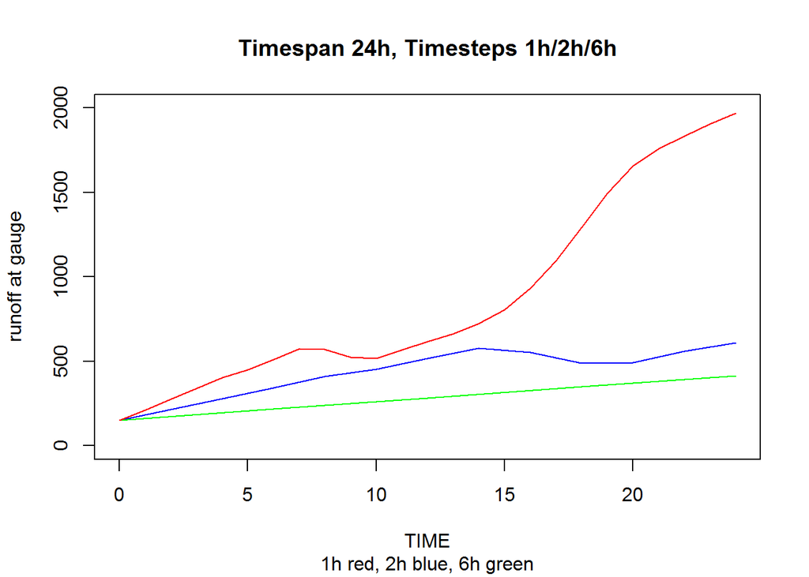

```r
path_saga <- "C:/Users/Christian/Desktop/saga_3.0.0_x64/saga_cmd.exe"
path_data <- "D:/Christian/Datenmanagement/data/gis/output/"
path_fun <- "D:/Christian/Datenmanagement/msc-phygeo-class-of-2016-Heimannc/fun/"
path_hydro <- paste0(path_data ,"hydro/")

span24_step_1h <- read.csv(paste0(path_hydro, "Pegel_runoff_1.csv"), sep = ",")
span24_step_2h <- read.csv(paste0(path_hydro, "Pegel_runoff_2.csv"), sep = ",")
span24_step_6h <- read.csv(paste0(path_hydro, "Pegel_runoff_6.csv"), sep = ",")

plot(span24_step_1h, ylim = c(0, 2000),col = "red", type = "n",
     main = "Timespan 24h, Timesteps 1h/2h/6h",
     sub = "1h red, 2h blue, 6h green",
     ylab = "runoff at gauge")

lines(span24_step_2h, col = "blue")
lines(span24_step_6h, col="green")
lines(span24_step_1h, col="red")
```

2. influence of the selected simulation time-step:

Die untersuchten Time.steps (1h, 2h, 6h) zeigen einerseits auf, dass je kürzer das Time-step Intervall ist, desto größer ist die Beregnungsmenge sowohl während der Beregnung als auch in dem simulierten Beregnungszeitraum insgesamt. Während beim 6h Zeitintervall ein linearer Anstieg der Beregnungsmenge zu erkennen ist, so zeigen die Abflussmengen in den Intervallen 1h und 2h nach rund 7h und 14h einen kurzzeitigen Rückgang des Abflusses am Pegel.

## Probleme und Fragen:

- Am DTM ausgeschnittenes catchment area des Pegels ist nicht als DTM Input des Moduls verwendbar - Wieso?
- Wieso gehen die Mengen obgleich einer stetigen Beregnung kurzzeitig zurück? Vermutung: Gibt es ein im Modul implementiertes Abbruchkriterium der Beregnung?